# DNAm Analysis

Dexamethasone-Stimulated Human Array Project

Anastasiia Hryhorzhevska

Max Planck Institute of Psychiatry  
anastasiia_hry@psych.mpg.de

Last compiled on 29 November, 2022

# Introduction

The introduction will come soon.

# DMPs

## Overview

The current analysis was performed for the linear mixed effects model (lmem) with

- **DNAm_SV**: first three methylation surrogate variables which represents methylation blood cell counts
- **SNP_PC**: first two genotype principal components
- **FDR**: False Discovery Rate was set to 0.01 based on the analysis of 450K
- **FC**: Fold Change was set to 0.02 based on the analysis of 450K

## Roadmap

The roadmap is being modified based on the consultations with different people :)

Final version will be placed later.

### The genotype roadmap:

1. Subset data:
   - MAF >= 5%
   - filter only SNPs
   - exclude MHC region
2. LD pruning based on pairwise correlation with the following options:
   - a window of 50 SNPs: to calculate LD between each pair of SNPs
   - remove one of a pair if the LD is greater than 0.2
   - short the window 5 SNPs forward
3. MDS / PCA in PLINK
4. Analysis in R

## Files location

The files’ locations will be added pnce the analysis is finished. Currently, the source data and calculated data are stored in the project working directory:

- **/data**: the source data folder
- **/output/data**: the folder with analysis results

## Analysis

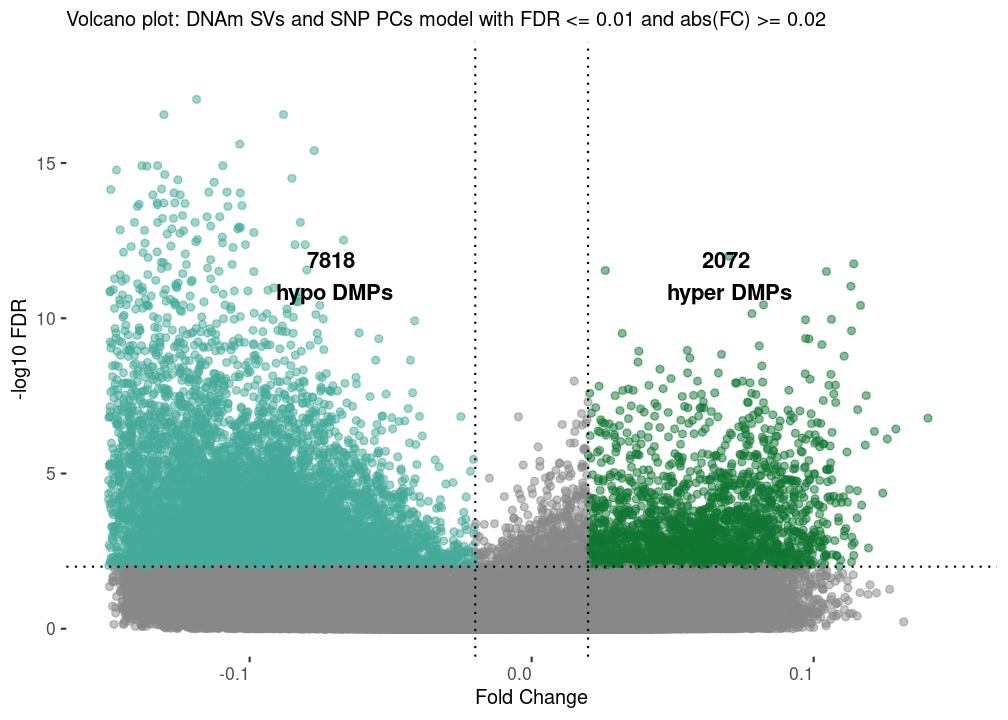

Model with DNAm BCCs and Genotype PCs

```r
fdr <- 0.01
fc <- 0.02

cbPalette <- c("#CC6677", "#DDCC77", "#117733", "#332288", "#AA4499", "#44AA99", "#999933", "#882255",
    "#661100", "#6699CC", "#888888")

VolcanoPlot(lmem.rslt, fdr, fc, "DNAm SVs and SNP PCs", cbPalette[c(11, 3, 6)])
```

# Significant DMPs

## DNAm PCA

- The PCA was performed to investigate the impact of additional surrogate variables capturing variation in DNA methylation on the association statistics for dex-associated DMPs.
- The first ten PCs were derived from the DMPs and compared to the available phenotype data and derived covariates to identify potential sources of additional variation between samples.

### Corplot

Heat-map of correlations between each PC (1-10) and the available phenotype information:

- **Dex**: a dexamethasone treatment group
- **Sex**: a sex group
- **Status**: a MDD status group
- **Age**
- **BMI**

and variables derived from the DNA methylation data:

- **DNAm BCC**: CD8T, CD4T, NK, Bcell, Mono, Gran - cellular proportion estimates from Houseman algorithm
- **DNAm Age**: an age estimated from DNAm data using Horvath algorithm
- **Smoking Score**: smoking score estimated from DNAm data using Elliot’s CpGs

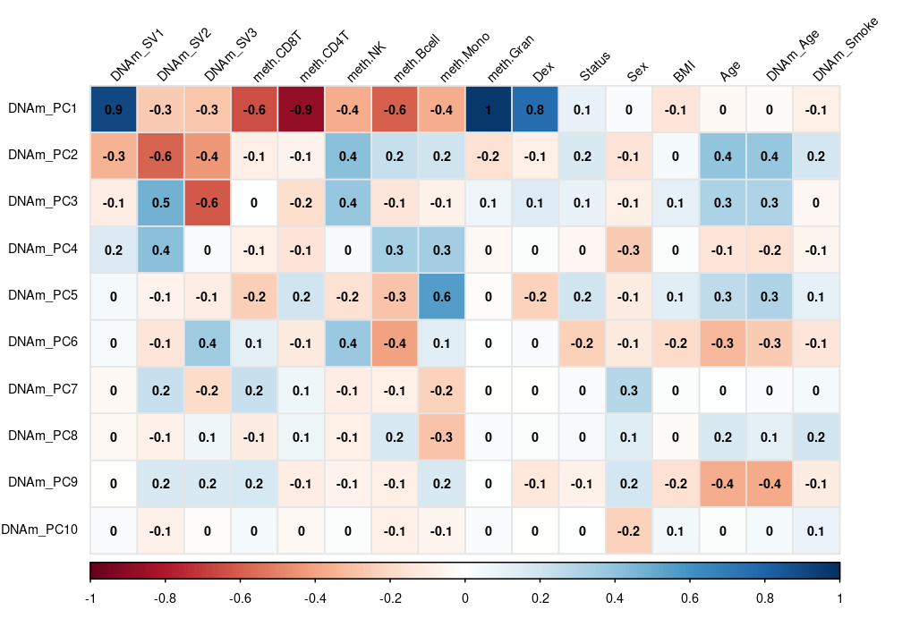

Relationship of the top 10 PCs derived from DNAm data with with available and derived covariates

```r
cor.mtrx.plt <- cor.mtrx[paste0("DNAm_PC", 1:10), c(paste0("DNAm_SV", 1:3),
                                                    paste("meth", colnames(bcc.meth), sep = "." ),
                                                    c("Dex", "Status", "Sex", "BMI", "Age", "DNAm_Age", "DNAm_Smoke"))]
par(cex = 1)
corrplot(cor.mtrx.plt,
         method = "color", cl.pos = "b", cl.cex = 0.6,
         addgrid.col = "gray90",
         addCoef.col = "black", number.cex = 0.6, number.digits = 1, # Add coefficient of correlation
         tl.col = "black",  tl.cex = 0.6, tl.srt = 45, tl.offset = 0.5, tl.pos = "dt", #Text label color and rotation
         sig.level = 0.01)
```

### Scree plot

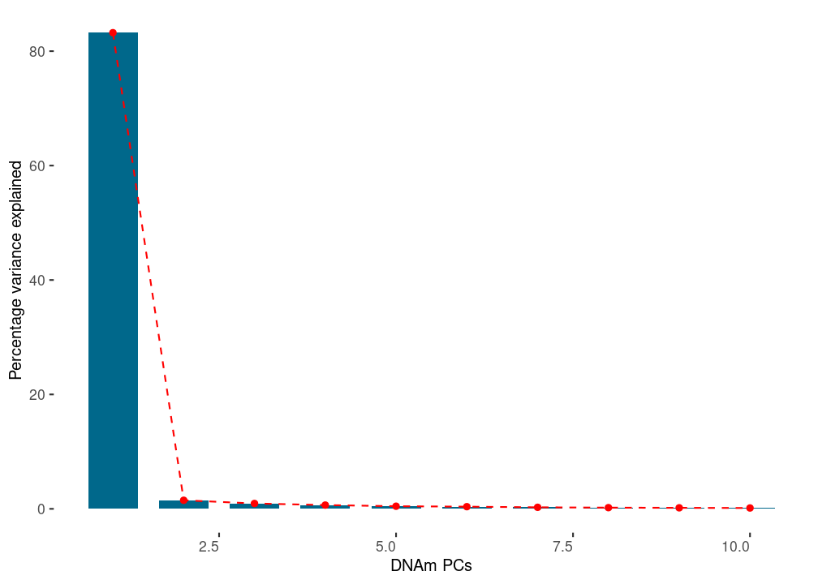

Percentage of variance explained by first 10 eigenvalues

```r
propvar.df <- data.frame(PC = 1:10, propvar)
ggplot(propvar.df, aes(PC, propvar)) + geom_bar(stat = "identity", width = 0.7, fill = "#00688B") + geom_line(colour = "red",
    linetype = "dashed") + geom_point(colour = "red") + xlab("DNAm PCs") + ylab("Percentage variance explained") +
    theme(panel.background = element_blank(), plot.title = element_text(size = 10), axis.title = element_text(size = 10),
        axis.text.x = element_text(angle = 0, hjust = 1), legend.position = "none")
```

### Dex separation

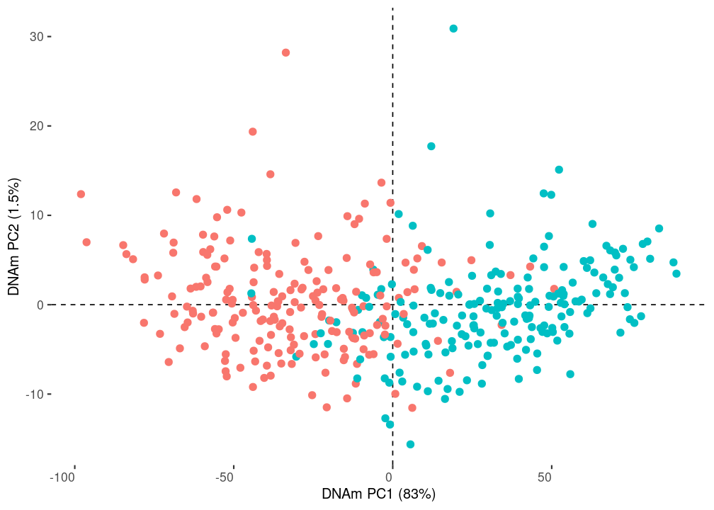

PCA plot demonstrating the DEX treatment separation based on significant DMPs

```r
plt.df <- data.frame((dnam.pcs), Group = as.factor(pheno$Dex), Sex = as.factor(pheno$Sex))

ggplot(data = plt.df, aes(DNAm_PC1, DNAm_PC2, col = Group)) + geom_vline(xintercept = 0, linetype = "dashed",
    size = 0.4) + geom_hline(yintercept = 0, linetype = "dashed", size = 0.4) + geom_point(size = 2,
    alpha = 1) + xlab(paste0("DNAm PC1 (", signif(propvar[1], 2), "%)")) + ylab(paste0("DNAm PC2 (",
    signif(propvar[2], 2), "%)")) + theme(panel.background = element_blank(), plot.title = element_text(size = 10),
    axis.title = element_text(size = 10), axis.text.x = element_text(angle = 0, hjust = 1), legend.position = "none")
```

### Sex separation

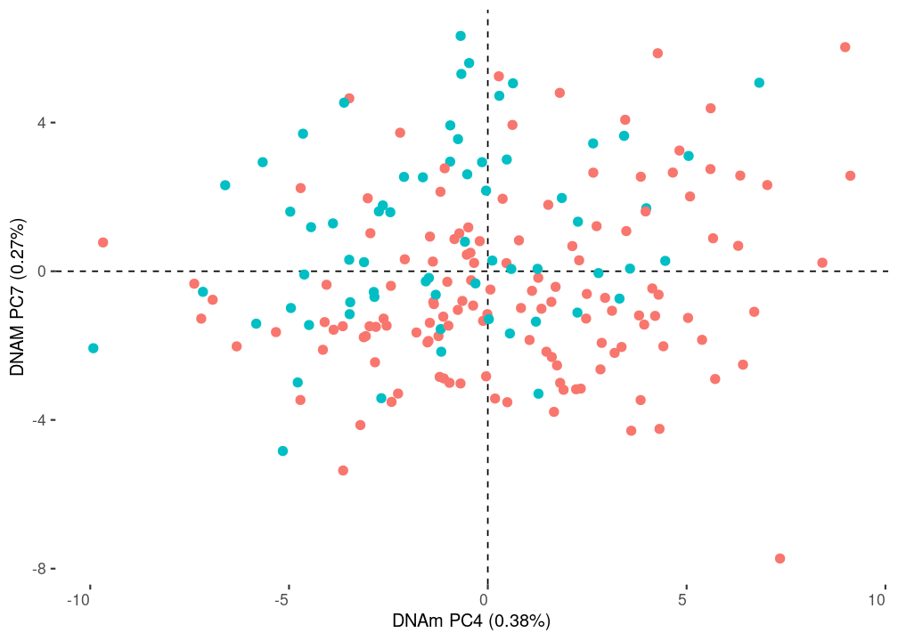

PCA plot demonstrating the SEX separation based on significant DMPs

```r
plt.df <- data.frame((dnam.pcs), Group = as.factor(pheno$Dex), Sex = as.factor(pheno$Sex))

ggplot(data = plt.df[plt.df$Group == 1, ], aes(DNAm_PC4, DNAm_PC7, col = Sex)) + geom_vline(xintercept = 0,
    linetype = "dashed", size = 0.4) + geom_hline(yintercept = 0, linetype = "dashed", size = 0.4) +
    geom_point(size = 2, alpha = 1) + xlab(paste0("DNAm PC4 (", signif(propvar[6], 2), "%)")) + ylab(paste0("DNAM PC7 (",
    signif(propvar[7], 2), "%)")) + theme(panel.background = element_blank(), plot.title = element_text(size = 10),
    axis.title = element_text(size = 10), axis.text.x = element_text(angle = 0, hjust = 1), legend.position = "none")
```

## Functional Annotation

### Manhattan plot

```r
# Load genomic locations
cpg.loc <- fread("/binder/mgp/workspace/2020_DexStim_Array_Human/dex-stim-human-array/data/integrative/matrixEQTL/cpg_locations.csv",
    select = c("CpG_ID", "chr", "pos"))

dmps.loc.df <- dmps.sign.anno.df[, c("PROBE_ID", "FDR")] %>%
    mutate(fdr = FDR)
dmps.loc.df <- left_join(dmps.loc.df, cpg.loc, by = c(PROBE_ID = "CpG_ID"))
```

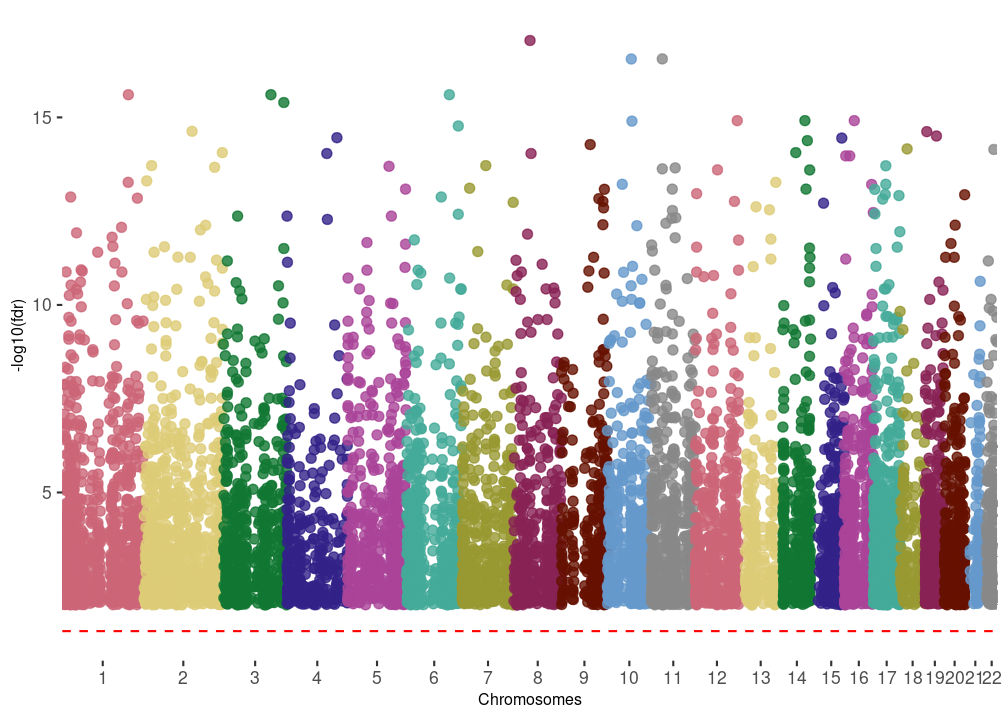

Manhattan plot for DMPs

```r
GetManhattanPlot(dmps.loc.df)
```

### Chromosomes DMPs

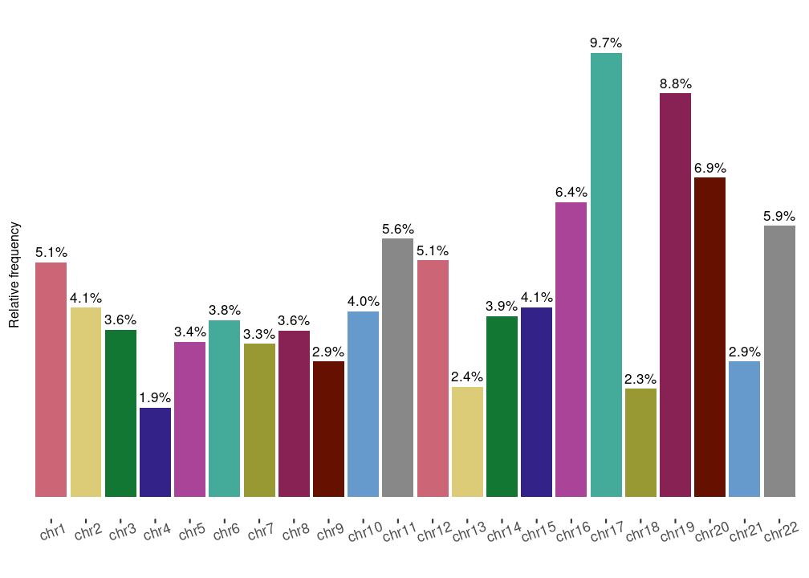

DMPs distribution across the chromosomes wieghted by the chromosomes’ length

```r
cbPalette <- c("#CC6677", "#DDCC77", "#117733", "#332288", "#AA4499", "#44AA99", "#999933", "#882255",
    "#661100", "#6699CC", "#888888")

ggplot(chr.cpgs.cnt, aes(x = chr, y = freq_cpg_chr, fill = chr)) + geom_bar(stat = "identity", position = position_dodge()) +
    geom_text(aes(label = scales::percent(freq_cpg_chr, accuracy = 0.1), y = freq_cpg_chr), stat = "identity",
        vjust = -0.5, size = 3) + scale_y_continuous(labels = scales::percent) + labs(title = "", x = " ",
    y = "Relative frequency") + theme(panel.background = element_blank(), plot.title = element_text(size = 8),
    axis.title = element_text(size = 8), axis.text.x = element_text(angle = 20, hjust = 0.5), axis.text.y = element_blank(),
    axis.ticks.y = element_blank(), legend.position = "none") + scale_fill_manual(values = rep(cbPalette,
    2))
```

### Chromosomes All

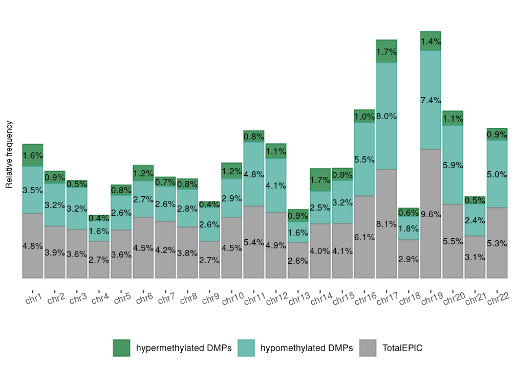

Distribution of the CpGs across the chromosomes wieghted by the chromosomes’ length

```r
cbPalette <- c("#CC6677", "#DDCC77", "#117733", "#332288", "#AA4499", "#44AA99", "#999933", "#882255",
    "#661100", "#6699CC", "#888888")

ggplot(chr.cpgs.cnt, aes(x = chr, y = freq_cpg_chr, fill = MethylStatus, color = MethylStatus)) + geom_bar(stat = "identity",
    position = "stack") + geom_text(aes(label = scales::percent(freq_cpg_chr, accuracy = 0.1), y = freq_cpg_chr),
    stat = "identity", position = position_stack(vjust = 0.5), size = 3, color = "black") + scale_y_continuous(labels = scales::percent) +
    labs(title = "", x = " ", y = "Relative frequency") + theme(legend.title = element_blank(), legend.position = "bottom",
    panel.grid.major = element_blank(), panel.background = element_blank(), plot.title = element_text(size = 8),
    axis.title = element_text(size = 8), axis.text.x = element_text(angle = 20, hjust = 0.5), axis.text.y = element_blank(),
    axis.ticks.y = element_blank()) + scale_color_manual(values = alpha(cbPalette[c(3, 6, 11)], 0.75)) +
    scale_fill_manual(values = alpha(cbPalette[c(3, 6, 11)], 0.75))
```

### CpG Islands

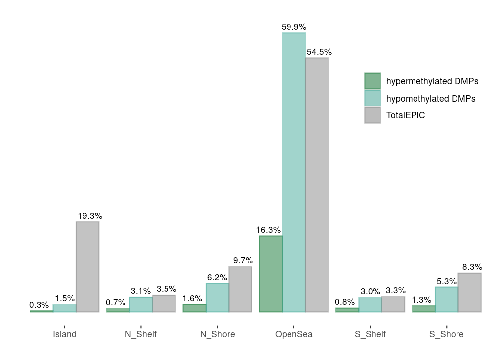

The ratio of all assessed EPIC CpGs versus dDMPs in different genomic regions in relation to CpG Island

```r
ggplot(dmps.cnt.df, aes(x = Relation_to_Island, y = freq, fill = MethylStatus, color = MethylStatus)) +
    geom_bar(stat = "identity", position = position_dodge()) + geom_text(aes(label = scales::percent(freq,
    accuracy = 0.1)), vjust = -0.5, position = position_dodge(1), size = 3, color = "black") + scale_y_continuous(labels = scales::percent) +
    labs(x = "", y = "", title = "") + theme(legend.title = element_blank(), legend.position = c(0.85,
    0.75), panel.grid.major = element_blank(), panel.background = element_blank(), plot.title = element_text(size = 8),
    axis.title = element_text(size = 8), axis.text.x = element_text(angle = 0, hjust = 0.5), axis.text.y = element_blank(),
    axis.ticks.y = element_blank()) + scale_color_manual(values = alpha(cbPalette[c(3, 6, 11)], 0.5)) +
    scale_fill_manual(values = alpha(cbPalette[c(3, 6, 11)], 0.5))
```

### Gene regions

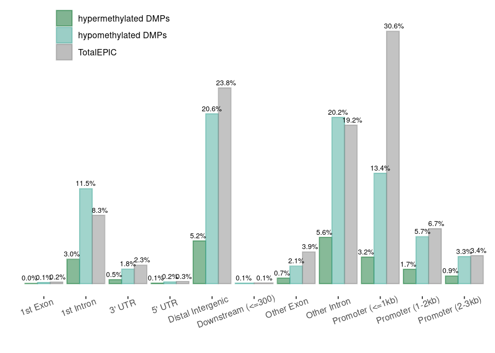

The ratio of all assessed EPIC CpGs versus dDMPs in different gene regions

```r
ggplot(dmps.cnt.df, aes(x = GeneGroup, y = freq, fill = MethylStatus, color = MethylStatus)) + geom_bar(stat = "identity",
    position = position_dodge()) + geom_text(aes(label = scales::percent(freq, accuracy = 0.1)), vjust = -0.5,
    position = position_dodge(1), size = 2.5, color = "black") + scale_y_continuous(labels = scales::percent) +
    labs(x = "", y = "", title = "") + theme(legend.title = element_blank(), legend.position = c(0.2,
    0.95), panel.grid.major = element_blank(), panel.background = element_blank(), plot.title = element_text(size = 8),
    axis.title = element_text(size = 8), axis.text.x = element_text(angle = 20, hjust = 0.75), axis.text.y = element_blank(),
    axis.ticks.y = element_blank()) + scale_color_manual(values = alpha(cbPalette[c(3, 6, 11)], 0.5)) +
    scale_fill_manual(values = alpha(cbPalette[c(3, 6, 11)], 0.5))
```